# Kaggle - House Prices

Step 2: Data Exploration

Gimme the Prize

2020-01-24

# Setup

```r
library(tidyverse)
library(gridExtra)
library(caret)  # for nearZeroVar()
library(e1071)  # for skewness()
library(broom)  # for tidy()
library(agricolae)  # for HSD.test()
library(corrplot)

d <- readRDS(file = "./ames_01.RDS")
```

# Univariate Analysis

In this section I will look at data distributions. For factor variables, I am interested in which are near-zero-variance predictors. For quantitative variables, I am looking for significant skew.

```r
col_is_ord <- map(d, ~ class(.x)[1] == "ordered") %>% unlist()

col_is_nom <- map(d, ~ class(.x)[1] == "factor") %>% unlist()

col_is_num <- map(d, ~ class(.x)[1] %in% c("integer", "numeric")) %>% unlist()
col_is_num <- col_is_num == TRUE & !(names(col_is_num) %in% c("Id", "SalePrice"))

col_is_oth <- colnames(d) %in% colnames(d)[!(col_is_ord | col_is_nom | col_is_num)]
names(col_is_oth) <- colnames(d)

assertthat::are_equal(
  sum(col_is_ord + col_is_nom + col_is_num + col_is_oth),
  ncol(d))
```

```
## [1] TRUE
```

## Factor Variables

I will inspect each factor variable, looking for near-zero-variance predictors. I won’t remove them here, but I might remove them in the modeling pre-process step if they cause zero-variance in cv folds (see discussion [here](https://www.r-bloggers.com/near-zero-variance-predictors-should-we-remove-them/)). `caret` has a nice function `nearZeroVar()` to identify near-zero variance predictors. It defines near-zero variance as a frequency ratio (ratio of the most common value frequency to the second most common value frequency) >= 19 and a percent of unique values <= 10% (see [caret package documentation](https://topepo.github.io/caret/index.html)). (DataCamp course [Machine Learning Toolbox](https://campus.datacamp.com/courses/machine-learning-toolbox/preprocessing-your-data?ex=13) suggests more aggressive thresholds of frequency ratio >= 2 and percent of unique values <= 20%).

```r
(nzv <- nearZeroVar(d[, col_is_ord | col_is_nom],
                    saveMetrics= TRUE,
                    freqCut = 99/5, uniqueCut = 10))
```

```
##                 freqRatio percentUnique zeroVar   nzv
## Alley           22.675000    0.10277492   FALSE  TRUE
## BldgType        10.682819    0.17129154   FALSE FALSE
## BsmtCond        21.360656    0.17129154   FALSE  TRUE
## BsmtExposure     4.555024    0.17129154   FALSE FALSE
## BsmtFinType1     1.002356    0.23980815   FALSE FALSE
## BsmtFinType2    23.742857    0.23980815   FALSE  TRUE
## BsmtQual         1.061208    0.17129154   FALSE FALSE
## CentralAir      13.892857    0.06851662   FALSE FALSE
## Condition1      15.310976    0.30832477   FALSE FALSE
## Condition2     222.230769    0.27406646   FALSE  TRUE
## Electrical      14.212766    0.17129154   FALSE FALSE
## ExterCond        8.488294    0.17129154   FALSE FALSE
## Exterior1st      2.277778    0.51387461   FALSE FALSE
## Exterior2nd      2.268456    0.51387461   FALSE FALSE
## ExterQual        1.836568    0.13703323   FALSE FALSE
## Fence            7.136778    0.17129154   FALSE FALSE
## FireplaceQu      1.908602    0.20554985   FALSE FALSE
## Foundation       1.059109    0.20554985   FALSE FALSE
## Functional      38.828571    0.23980815   FALSE  TRUE
## GarageCond      16.691824    0.20554985   FALSE FALSE
## GarageFinish     1.516646    0.13703323   FALSE FALSE
## GarageQual      16.377358    0.20554985   FALSE FALSE
## GarageType       2.211810    0.23980815   FALSE FALSE
## Heating        106.444444    0.20554985   FALSE  TRUE
## HeatingQC        1.742124    0.17129154   FALSE FALSE
## HouseStyle       1.686927    0.27406646   FALSE FALSE
## KitchenQual      1.297133    0.13703323   FALSE FALSE
## LandContour     21.850000    0.13703323   FALSE  TRUE
## LandSlope       22.224000    0.10277492   FALSE  TRUE
## LotConfig        4.174168    0.17129154   FALSE FALSE
## LotShape         1.920455    0.13703323   FALSE FALSE
## MasVnrType       2.007964    0.13703323   FALSE FALSE
## MiscFeature     29.621053    0.17129154   FALSE  TRUE
## MoSold           1.127803    0.41109969   FALSE FALSE
## MSSubClass       1.876522    0.54813292   FALSE FALSE
## MSZoning         4.926087    0.17129154   FALSE FALSE
## Neighborhood     1.659176    0.85645769   FALSE FALSE
## PavedDrive      12.226852    0.10277492   FALSE FALSE
## PoolQC         727.250000    0.13703323   FALSE  TRUE
## RoofMatl       125.043478    0.27406646   FALSE  TRUE
## RoofStyle        4.192377    0.20554985   FALSE FALSE
## SaleCondition    9.804082    0.20554985   FALSE FALSE
## SaleType        10.569038    0.30832477   FALSE FALSE
## Street         242.250000    0.06851662   FALSE  TRUE
## Utilities     2918.000000    0.06851662   FALSE  TRUE
## CondRoad        10.200000    0.10277492   FALSE FALSE
## CondRail        29.092784    0.06851662   FALSE  TRUE
## CondPos         53.943396    0.10277492   FALSE  TRUE
## Cond             7.194842    0.10277492   FALSE FALSE
```

```r
nzv_colnames <- rownames(nzv[nzv$nzv == TRUE,])
```

There are 15 factor variables with near-zero variance. Here are distribution bar plots of the ordinal factor variables. The NZVs are colored gold.

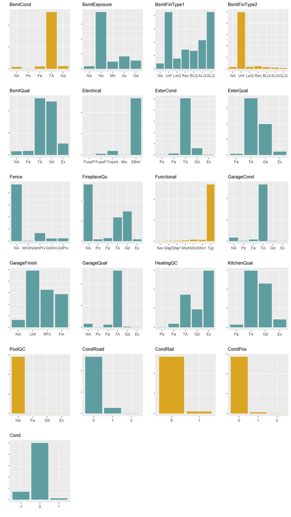

```r
p <- map(colnames(d[,col_is_ord]),
         ~ ggplot(d, aes_string(x = .x)) +
           geom_bar(fill = ifelse(.x %in% nzv_colnames, "goldenrod", "cadetblue")) +
           labs(y = "", x = "", title = .x) +
           theme(axis.text.y=element_blank(),
                 plot.title = element_text(size = 10)))
exec(grid.arrange, ncol = 4, !!!p)
```

And here are the distribution bar plots of the nominal factor variables. The NZVs are colored gold.

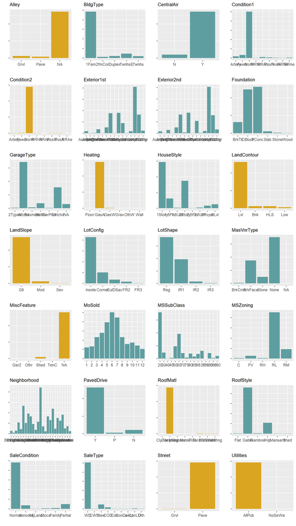

```r
p <- map(colnames(d[,col_is_nom]),
         ~ ggplot(d, aes_string(x = .x)) +
           geom_bar(fill = ifelse(.x %in% nzv_colnames, "goldenrod", "cadetblue")) +
           labs(y = "", x = "", title = .x) +
           theme(axis.text.y=element_blank(),
                 plot.title = element_text(size = 10)))
exec(grid.arrange, ncol = 4, !!!p)
```

## Quantitative Variables

Skew can contribute to violation of linearity in linear regressions. I’ll check which variables have significant skew. Skew between 0.5 and 1.0 is generally considered moderate, and skew greater than 1 severe. In the following charts, the moderately skewed predictors are colored gold and the severely skewed predictors are colored red.

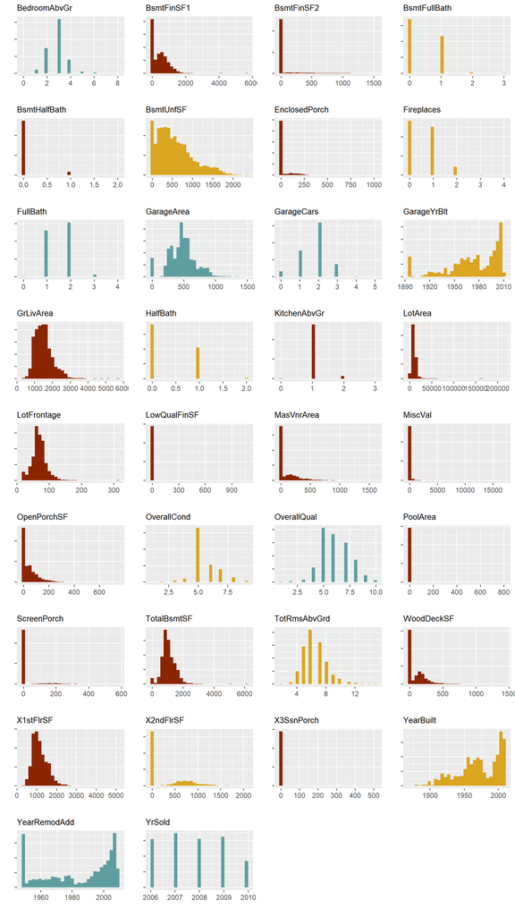

```r
col_skew <- map(d[, col_is_num], skewness) %>% unlist()
col_skew_is_mod <- names(col_skew[abs(col_skew) > .5 & abs(col_skew) <= 1.0])
col_skew_is_high <- names(col_skew[abs(col_skew) > 1.0])
p <- map(colnames(d[,col_is_num]),
         ~ ggplot(d, aes_string(x = .x)) +
           geom_histogram(fill = case_when(.x %in% col_skew_is_mod ~ "goldenrod",
                                           .x %in% col_skew_is_high ~ "orangered4",
                                           TRUE ~ "cadetblue")) +
           labs(y = "", x = "", title = .x) +
           theme(axis.text.y=element_blank(),
                 plot.title = element_text(size = 10)))
exec(grid.arrange, ncol = 4, !!!p)
```

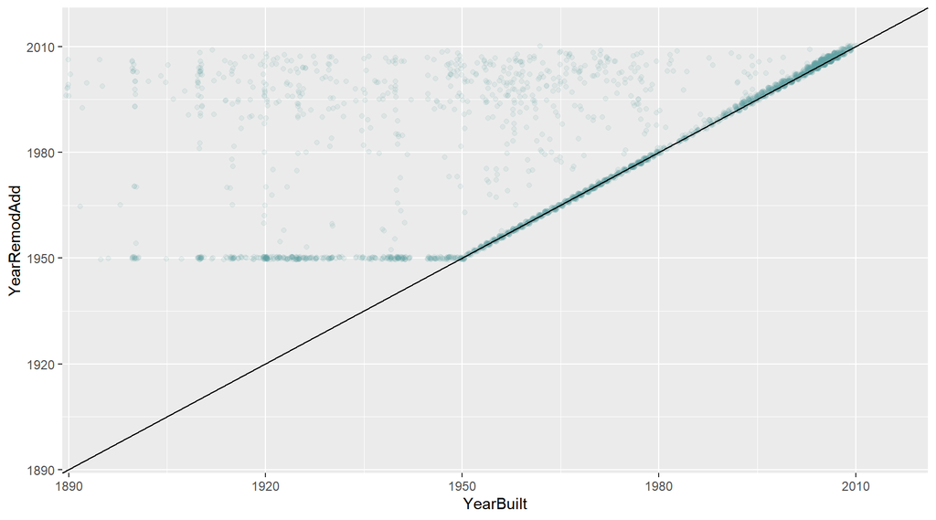

```r
ggplot(d, aes(x = YearBuilt, y = YearRemodAdd)) +
  geom_jitter(alpha = 0.1, color = "cadetblue") +
  geom_abline(na.rm = TRUE) +
  coord_cartesian(xlim = c(1895, 2015), ylim = c(1895, 2015))
```

For some reason, `YearRemodAdd` is floored at 1950. I’m going to change all instances of `YearRemodAdd` = 1950 to the value of `YearBuilt`.

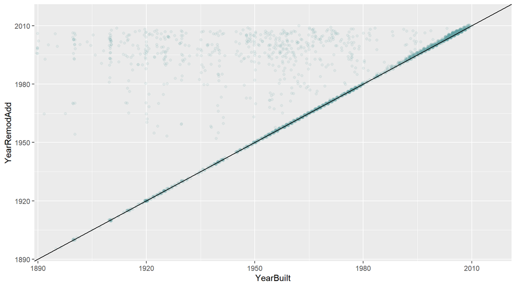

```r
d$YearRemodAdd = ifelse(d$YearRemodAdd > 1950, d$YearRemodAdd, d$YearBuilt)

ggplot(d, aes(x = YearBuilt, y = YearRemodAdd)) +
  geom_jitter(alpha = 0.1, color = "cadetblue") +
  geom_abline(na.rm = TRUE) +
  coord_cartesian(xlim = c(1895, 2015), ylim = c(1895, 2015))
```

# Bi-Variate Analysis

In this section I will look at inter-variable relationships. For factor variables, I am interested in which levels have significantly different mean `SalePrice` values. For quantitative variables, I am looking for linear relationships with `SalePrice` and low correlations with each other.

## Factor Variables

For each factor variable I will construct box-plot of `SalePrice` and conduct a post-hoc test on the factor levels to determine which groups differ from others. For groups with no significant difference, I can collapse the levels, or leave them alone and allow the penalization models to reduce their coefficients or the tree models to disregard them.

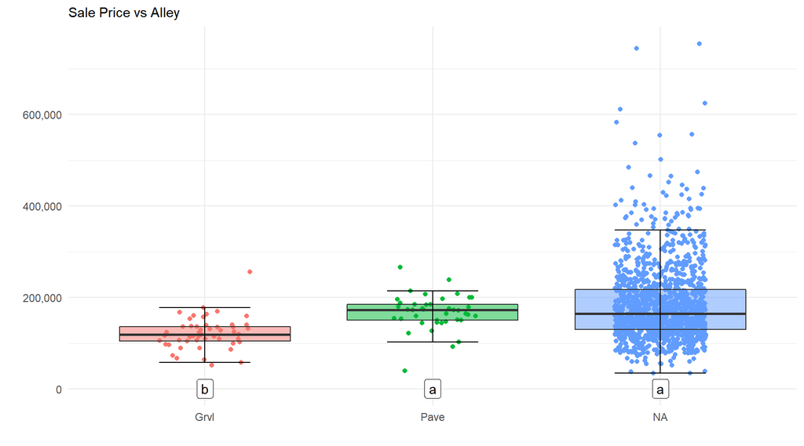

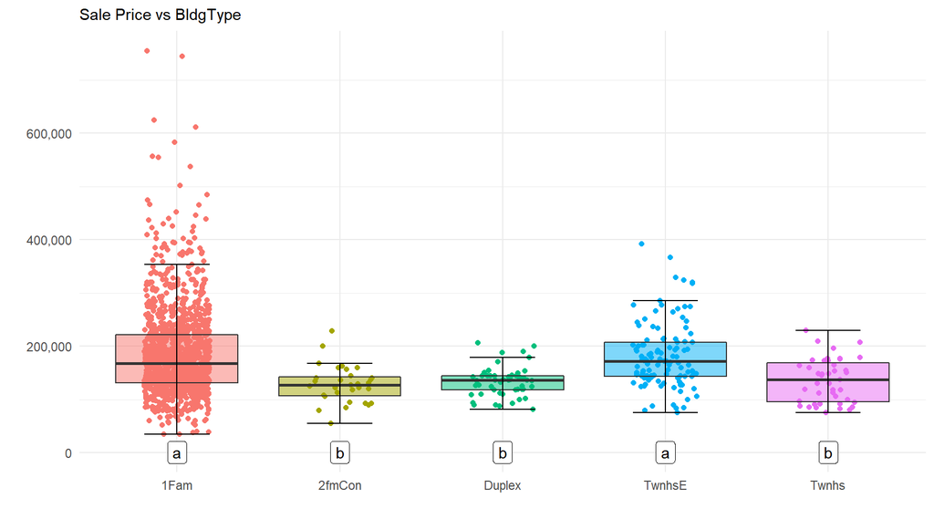

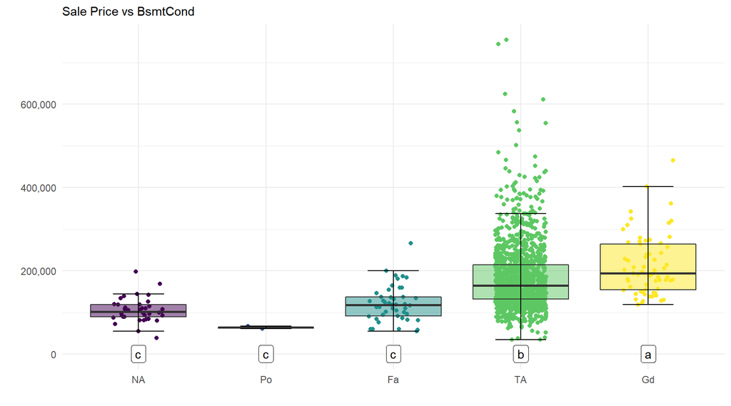

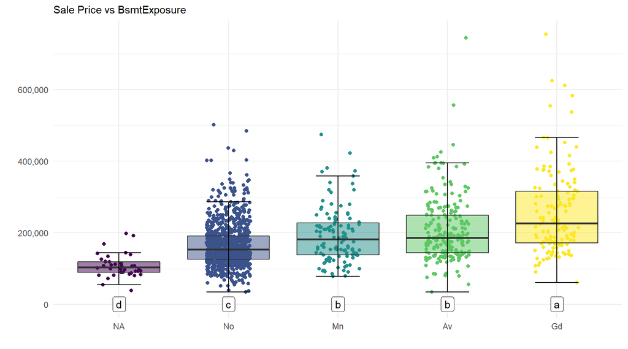

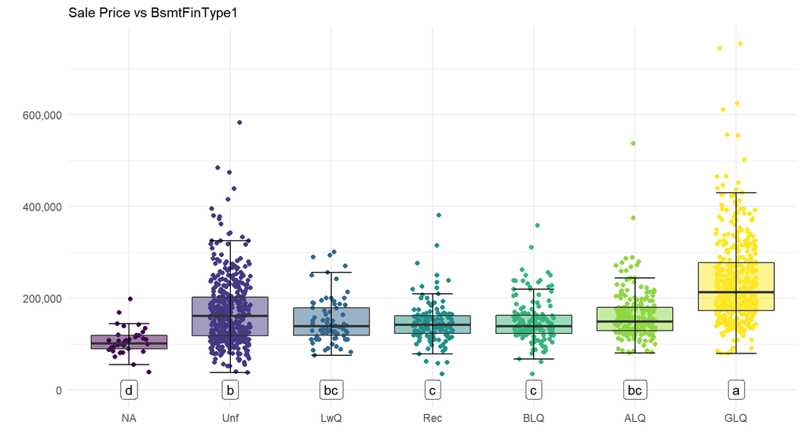

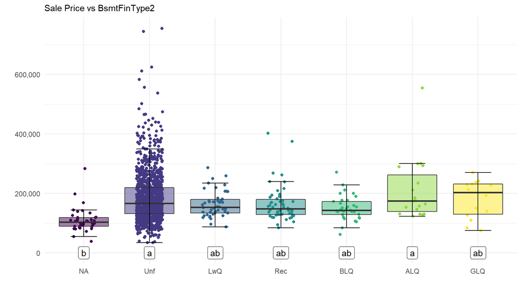

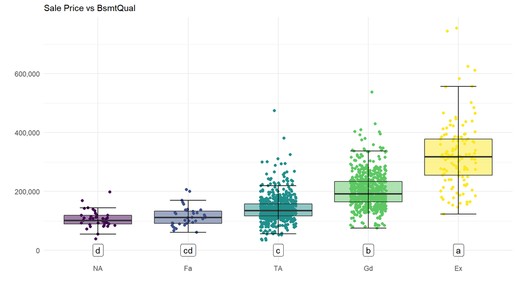

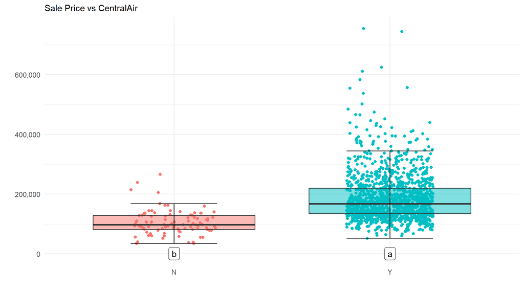

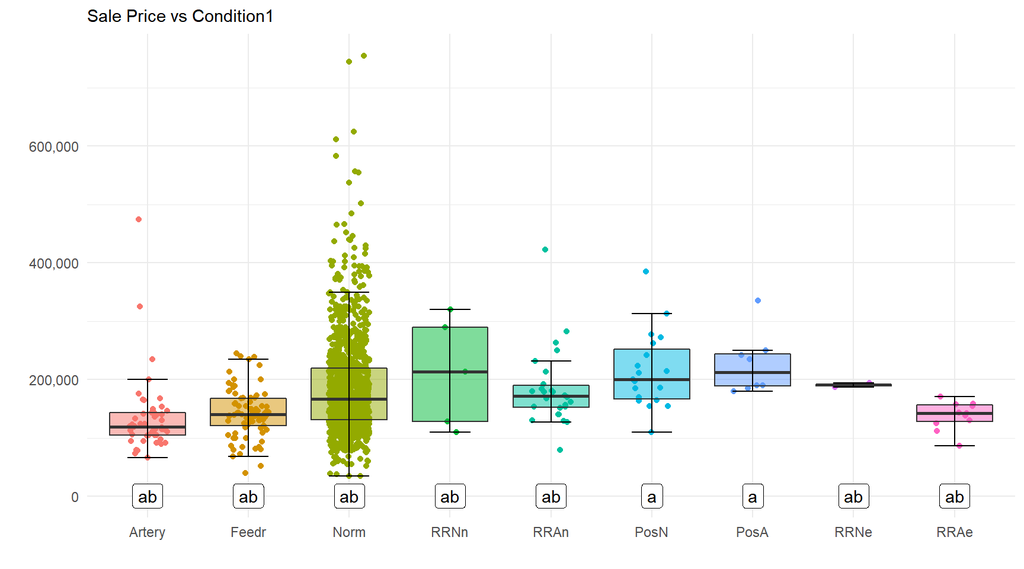

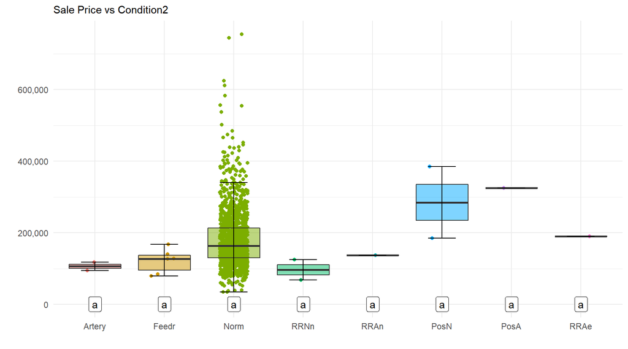

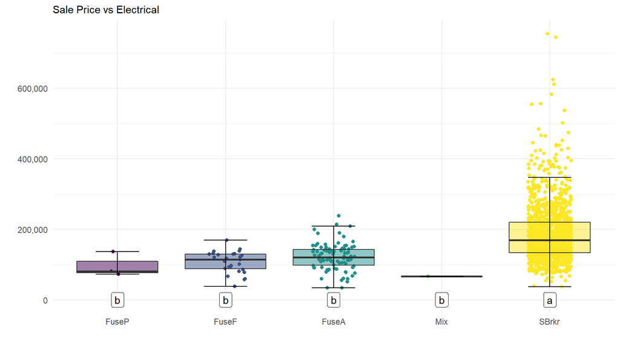

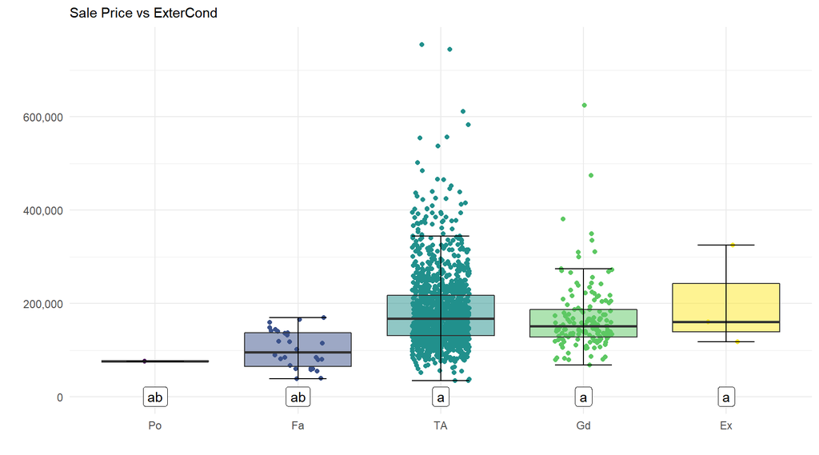

[37 more figures not shown]

```r
for(i in names(col_is_nom[col_is_nom == TRUE | col_is_ord])) {
  myHSDLvl <- aov(as.formula(paste0("SalePrice ~ ", i)), data = d[d$Set == "train",]) %>%
    HSD.test(trt = i, console = FALSE) %>%
    .$groups %>%
    as.data.frame() %>%
    rownames_to_column()
  colnames(myHSDLvl) <- c(i, "SalePrice", "groups")
  myHSDLvl$SalePrice <- 1000

  p <- d %>%
    filter(Set == "train") %>%
    ggplot(aes_string(y = "SalePrice", x = i)) +
    geom_jitter(aes_string(color = i), width = 0.2) +
    geom_boxplot(aes_string(fill = i), alpha = 0.5, outlier.shape = NA) +
    stat_boxplot(geom = "errorbar", width = 0.4) +
    geom_label(data = myHSDLvl, aes_string(label = "groups")) +
    scale_y_continuous(labels = scales::comma) +
    theme_minimal() +
    theme(legend.position = "none") +
    labs(title = paste("Sale Price vs", i), x = "", y = "") +
    theme(plot.title = element_text(size = 11))
  print(p)
}
```

## Quantitative Variables

For each quantitative variable, I am interested in its correlation with `SalePrice` and with other quantitative variables.

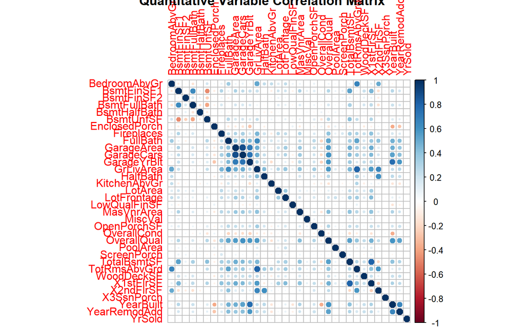

```r
corrplot(cor(d[, col_is_num]),
         title = "Quantitative Variable Correlation Matrix")
```

# Add Features

I will apply my (scant) subject matter knowledge to propose new variables derived from others.

## Collapse NZV

I’ll propose variables that collapse levels of the NZV factor vars identified above (at least for the ones that seem to make sense to collapse).

```r
nzv_colnames
```

```
##  [1] "Alley"        "BsmtCond"     "BsmtFinType2" "Condition2"
##  [5] "Functional"   "Heating"      "LandContour"  "LandSlope"
##  [9] "MiscFeature"  "PoolQC"       "RoofMatl"     "Street"
## [13] "Utilities"    "CondRail"     "CondPos"
```

```r
d <- d %>%
  mutate(HasAlley = as.factor(ifelse(as.character(Alley) == "NA", 0, 1)),
         IsFunctional = as.factor(ifelse(as.character(Functional) == "Typ", 1, 0)),
         GasHeating = as.factor(ifelse(as.character(Heating) == "GasA", 1, 0)),
         LvlLand = as.factor(ifelse(as.character(LandContour) == "Lvl", 1, 0)),
         GtlSlope = as.factor(ifelse(as.character(LandSlope) == "Gtl", 1, 0)),
         HasMiscFtr = as.factor(ifelse(as.character(MiscFeature) == "NA", 0, 1))) %>% data.frame()
```

## Summary Features

I’ll combine features summary features.

```r
d <- d %>%
  mutate(TotalSF = TotalBsmtSF + GrLivArea,
         TotalBath = BsmtFullBath + 0.5 * BsmtHalfBath + FullBath + 0.5 * HalfBath,
         AbvGrdSFperRm = GrLivArea / TotRmsAbvGrd,
         HasBsmt = as.factor(ifelse(TotalBsmtSF == 0, 0, 1)),
         HasGarage = as.factor(ifelse(GarageArea == 0, 0, 1))
  ) %>% data.frame()
```

## Log(SalePrice)

I’ll log-transform `SalePrice` because that is what we are predicting, and because `SalePrice` is skewed.

```r
d <- d %>%
  mutate(logSalePrice = log(SalePrice)) %>%
  data.frame()
```

Now that the data tranformation tasks are complete, I’ll split `d` back into `d.train` and `d.test`.

```r
d <- d %>% select(Set, Id, SalePrice, logSalePrice, sort(names(d))) %>% data.frame()
d.train <- d[d$Set == "train", which(colnames(d) != "Set")]
d.test <- d[d$Set == "test", which(colnames(d) != "Set")]
```

# Handle Outliers

Now I’ll look at influential outliers. When building a predictive model, I only need to address influential outliers for variables that are likely to be important in the final model. I’ll identify the most likely important variables with a correlation matrix of the numerical predictors. For every variable with correlation >= 0.5 (a moderate correlation), I’ll check the variable distribution to see whether any influential outliers exist.

```r
col_is_num <- map(d.train, ~ class(.x)[1] %in% c("integer", "numeric")) %>% unlist()
col_is_num <- col_is_num == TRUE & !(names(col_is_num) %in% c("Id", "logSalePrice"))
(var_num.cor <- cor(d.train[, col_is_num]) %>%
    data.frame() %>%
    select(SalePrice) %>%
    data.frame(Variable = rownames(.), Corr = .) %>%
    filter(abs(SalePrice) >= 0.5 & Variable != "SalePrice") %>%
    arrange(desc(SalePrice)))
```

```
##         Variable SalePrice
## 1    OverallQual 0.7909816
## 2        TotalSF 0.7789588
## 3      GrLivArea 0.7086245
## 4     GarageCars 0.6404092
## 5      TotalBath 0.6317311
## 6     GarageArea 0.6234314
## 7    TotalBsmtSF 0.6135806
## 8      X1stFlrSF 0.6058522
## 9       FullBath 0.5606638
## 10 AbvGrdSFperRm 0.5406452
## 11  TotRmsAbvGrd 0.5337232
## 12     YearBuilt 0.5228973
## 13   GarageYrBlt 0.5152969
```

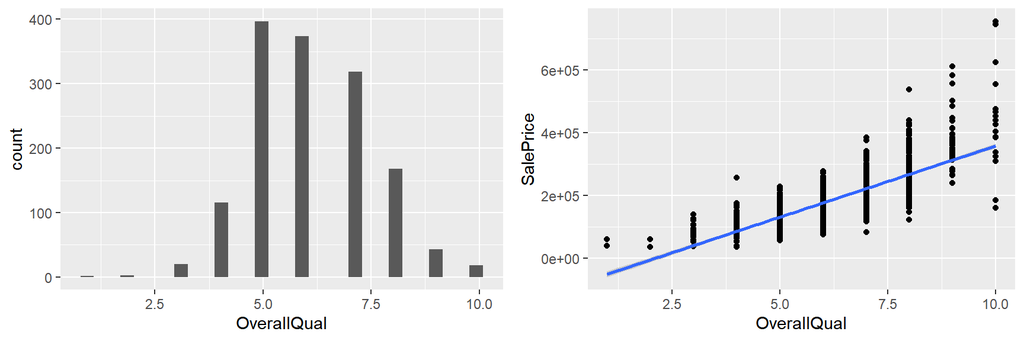

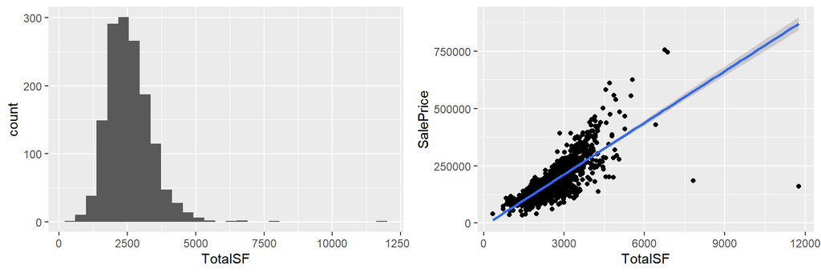

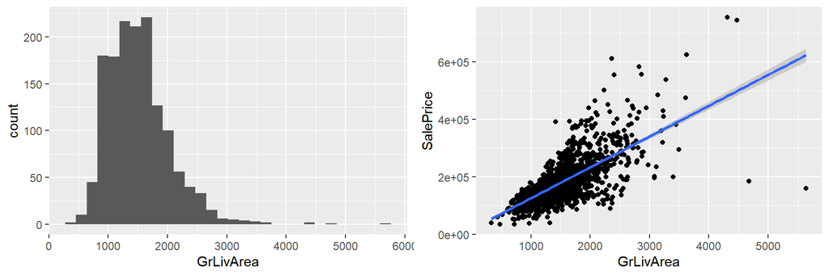

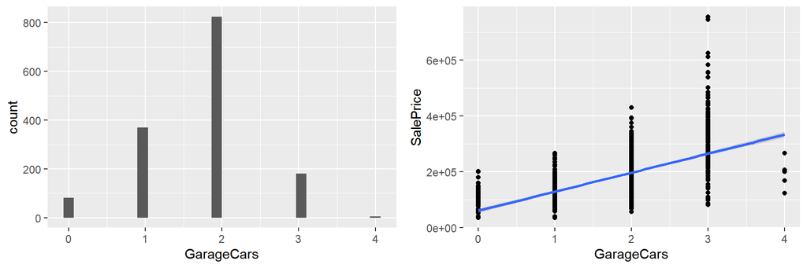

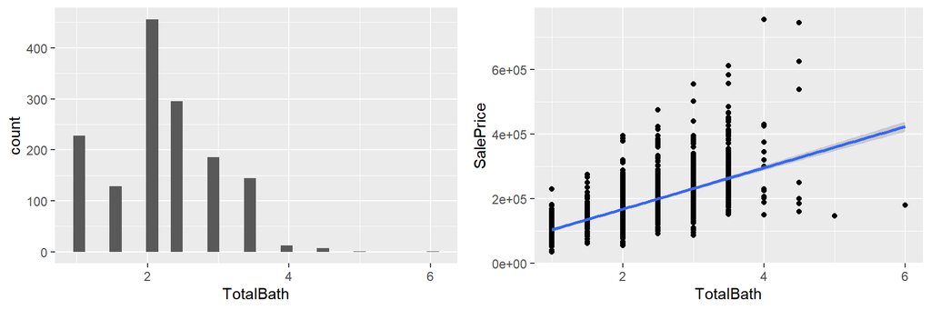

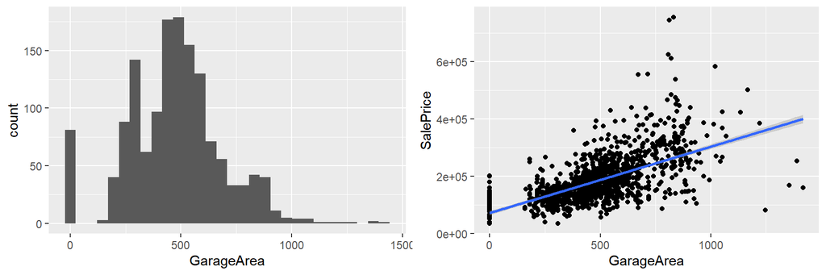

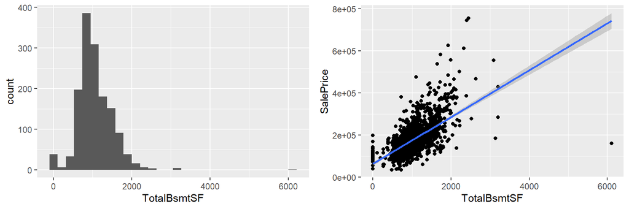

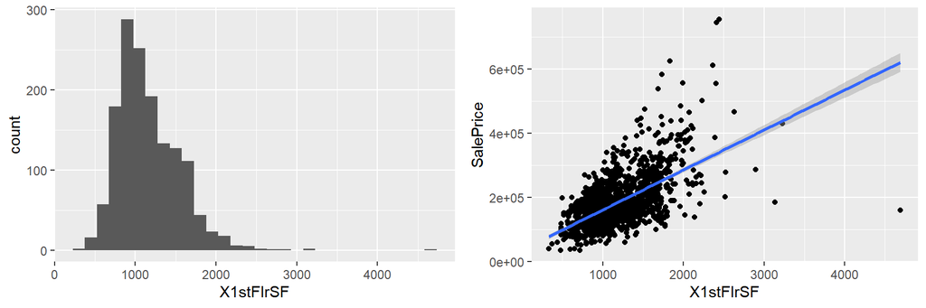

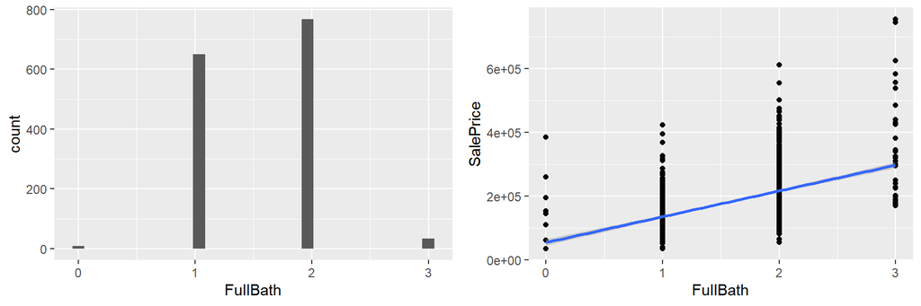

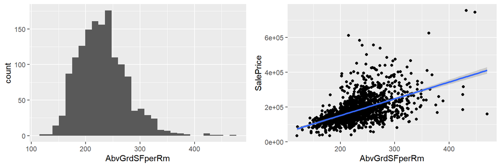

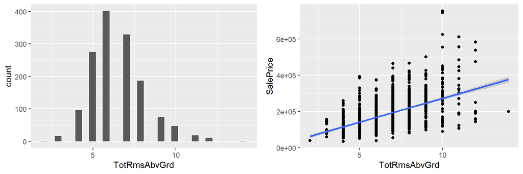

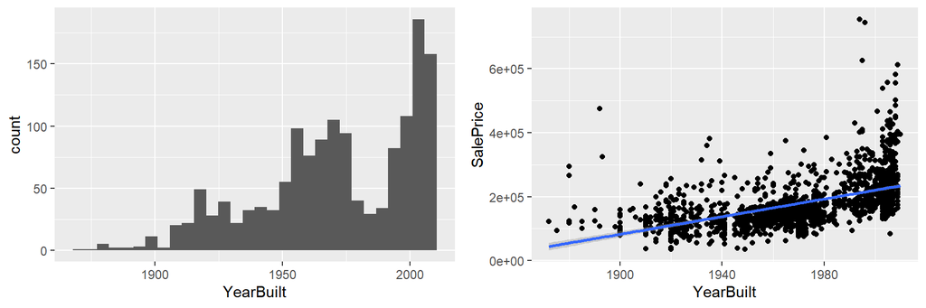

[1 more figures not shown]

```r
for (x in as.character(var_num.cor$Variable)) {
  p1 <- ggplot(d.train, aes_string(x = x)) + geom_histogram() + labs(x = x)
  p2 <- ggplot(d.train, aes_string(x = x, y = "SalePrice")) + geom_point() + labs(x = x) +
    geom_smooth(method = "lm", se = TRUE, na.rm = TRUE)
  grid.arrange(p1, p2, ncol = 2)
}
```

I count six potential influential outliers. They are based on the union of the conditions in the filter condition below. I can see why the author recommends dropping `GrLivArea` > 4000 - it captures 4 of them.

```r
d.train %>% filter(TotalSF >= 6000 |
                     GrLivArea >= 4000 |
                     TotalBsmtSF >= 6000 |
                     X1stFlrSF >= 4000 |
                     TotRmsAbvGrd >= 14) %>%
  select(Id, SalePrice, TotalSF, GrLivArea, TotalBsmtSF, X1stFlrSF, TotRmsAbvGrd)
```

```
##     Id SalePrice TotalSF GrLivArea TotalBsmtSF X1stFlrSF TotRmsAbvGrd
## 1  497    430000    6428      3228        3200      3228           10
## 2  524    184750    7814      4676        3138      3138           11
## 3  636    200000    4835      3395        1440      1440           14
## 4  692    755000    6760      4316        2444      2444           10
## 5 1183    745000    6872      4476        2396      2411           10
## 6 1299    160000   11752      5642        6110      4692           12
```

```r
d.train <- d.train %>% filter(TotalSF < 6000 &
                                GrLivArea < 4000 &
                                TotalBsmtSF < 6000 &
                                X1stFlrSF < 4000 &
                                TotRmsAbvGrd < 14 &
                                LotArea < 100000) %>%
  data.frame()
```

# Save Work

Save the data as an input to the next step, exploratory data analysis

```r
saveRDS(d.train, file = "./ames_02_train.RDS")
saveRDS(d.test, file = "./ames_02_test.RDS")
```